# Prediction Assignment

Fahmi Adi Nugraha

05/01/2020

# Overview

The goal of this assignment is to train a machine learning algorithm to identify the quality of a specific exercise routine, namely, bicep curls using dumbbells. In the provided data, participants of a study were trained to perform bicep curls correctly as well as incorrectly, emulating four common mistakes. Each of these five “types” of bicep curls have been given their own category labeled “A” through “E”. Throughout each session, the motion of each participant was measured using accelerometers worn on the arms and waist. The trained machine learning algorithm should be able to correctly distiguish between each category of bicep curls using the measurements from the accelerometer.

# EDA and Data cleaning

## Feature removal

### Remove features with missing values

We begin the entire process of training a machine learning algorithm by tidying up the data. We will first load the data and then split it into training and test sets with a 70/30 ratio.

```r
# Load the necessary libraries
library(tidyverse)
library(magrittr)
library(caret)

# Load the data
pml_data <- read_csv('pml-training.csv')

# Split data into training and test sets
set.seed(1234)

in_train <- createDataPartition(pml_data$classe, p = 0.7, list = F)
pml_train <- pml_data[in_train, ]
pml_test <- pml_data[-in_train, ]
```

A quick pass of the training set through the `glimpse()` function reveals a large number of features with missing values.

```r
# Glimpse training data
pml_train %>% glimpse()
```

```
## Rows: 13,737
## Columns: 160
## $ X1                       <dbl> 3, 4, 5, 7, 9, 10, 11, 13, 14, 15, 16, 17,...
## $ user_name                <chr> "carlitos", "carlitos", "carlitos", "carli...
## $ raw_timestamp_part_1     <dbl> 1323084231, 1323084232, 1323084232, 132308...
## $ raw_timestamp_part_2     <dbl> 820366, 120339, 196328, 368296, 484323, 48...
## $ cvtd_timestamp           <chr> "05/12/2011 11:23", "05/12/2011 11:23", "0...
## $ new_window               <chr> "no", "no", "no", "no", "no", "no", "no", ...
## $ num_window               <dbl> 11, 12, 12, 12, 12, 12, 12, 12, 12, 12, 12...
## $ roll_belt                <dbl> 1.42, 1.48, 1.48, 1.42, 1.43, 1.45, 1.45, ...
## $ pitch_belt               <dbl> 8.07, 8.05, 8.07, 8.09, 8.16, 8.17, 8.18, ...
## $ yaw_belt                 <dbl> -94.4, -94.4, -94.4, -94.4, -94.4, -94.4, ...
## $ total_accel_belt         <dbl> 3, 3, 3, 3, 3, 3, 3, 3, 3, 3, 3, 3, 3, 3, ...
## $ kurtosis_roll_belt       <chr> NA, NA, NA, NA, NA, NA, NA, NA, NA, NA, NA...
## $ kurtosis_picth_belt      <chr> NA, NA, NA, NA, NA, NA, NA, NA, NA, NA, NA...
```

[output cut: 147 more lines]

We can get an exact count of the number of missing values in each feature as shown below.

```r
# Get counts of missing values in each feature
pml_missing <- colSums(is.na(pml_train)) %>%
    enframe(name = 'col_name', value = 'num_missing')
pml_missing_counts <- pml_missing %>% count(num_missing)

pml_missing_counts %>%
    knitr::kable() %>%
    kableExtra::kable_styling(bootstrap_options = 'striped',
                              position = 'center')
```

| num_missing | n |
| --- | --- |
| 0 | 60 |
| 13451 | 91 |
| 13452 | 2 |
| 13453 | 5 |
| 13508 | 2 |

```r
# Get column names
cols_missing_data <- pml_missing %>% filter(num_missing > 0) %>%
    pluck('col_name')

# Remove all cols with missing data
pml_train %<>% select(-all_of(cols_missing_data))
```

### Remove unnecessary features

Out of the remaining features, the following seem fit for removal

- `X1`
- `user_name`
- `raw_timestamp_part_1`
- `raw_timestamp_part_2`
- `cvtd_timestamp`
- `new_window`
- `num_window`

#### `X1`

If we look at this variable, we see that it’s simply a copy of the index of the original data structure that was used to store the data.

```r
pml_train %>% select(X1) %>% head(10)
```

```
## # A tibble: 10 x 1
##       X1
##    <dbl>
##  1     3
##  2     4
##  3     5
##  4     7
##  5     9
##  6    10
##  7    11
##  8    13
##  9    14
## 10    15
```

For this reason, it seems safe to omit this feature.

```r
pml_train %<>% select(-X1)
```

It’s my understanding that the ultimate goal of our trainined algorithm is to be able to predict the quality of the bicep curls irrespective of who performed them or when they were performed. Thus, it seems reasonable to remove these features.

```r
cols_name_timestamp <- c('user_name', 'raw_timestamp_part_1',
                         'raw_timestamp_part_2', 'cvtd_timestamp')
pml_train %<>% select(-all_of(cols_name_timestamp))
```

#### `new_window` and `num_window`

These “features” are actually the values of the parameters of the sliding window that the researchers in the original study used to extract features related to the euler angles of each sensor. Due to this, it seems safe to assume that these values are not related at all to the quality of the bicep curls and can be removed.

```r
cols_window <- c('new_window', 'num_window')
pml_train %<>% select(-all_of(cols_window))
```

## Convert `classe` feature to categorical variable

If we go back to the output of the glimpse function from one of the previous sub-sections, we see that the `classe` feature is of type `char`. We’ll need to convert this feature to type `fct` in order for our classification algorithms to work properly. We will also convert the `classe` feature in the test set to a factor as well in order to obtain model predictions later on.

```r
pml_train %<>% mutate(classe = as.factor(classe))
pml_test %<>% mutate(classe = as.factor(classe))
```

## Identify outliers and other problems with the remaining features

Here we’ll quickly print out summary statistics and rough histograms for each of the remaining features.

```r
# Load the skimr library
library(skimr)

# Print summary
pml_train %>% select(-classe) %>% skim()
```

Data summary

| Name | Piped data |
| --- | --- |
| Number of rows | 13737 |
| Number of columns | 52 |
| _______________________ |  |
| Column type frequency: |  |
| numeric | 52 |
| ________________________ |  |
| Group variables | None |

**Variable type: numeric**

| skim_variable | n_missing | complete_rate | mean | sd | p0 | p25 | p50 | p75 | p100 | hist |
| --- | --- | --- | --- | --- | --- | --- | --- | --- | --- | --- |
| roll_belt | 0 | 1 | 64.13 | 62.76 | -28.60 | 1.10 | 113.00 | 123.00 | 162.00 | ▇▁▁▅▅ |
| pitch_belt | 0 | 1 | 0.41 | 22.25 | -53.90 | 1.79 | 5.28 | 15.00 | 60.30 | ▃▁▇▃▁ |
| yaw_belt | 0 | 1 | -11.69 | 94.89 | -179.00 | -88.30 | -13.40 | 10.80 | 179.00 | ▁▇▅▁▃ |
| total_accel_belt | 0 | 1 | 11.28 | 7.76 | 0.00 | 3.00 | 17.00 | 18.00 | 29.00 | ▇▁▂▆▁ |
| gyros_belt_x | 0 | 1 | -0.01 | 0.21 | -1.04 | -0.03 | 0.03 | 0.11 | 2.22 | ▁▇▁▁▁ |
| gyros_belt_y | 0 | 1 | 0.04 | 0.08 | -0.64 | 0.00 | 0.02 | 0.11 | 0.64 | ▁▁▇▁▁ |
| gyros_belt_z | 0 | 1 | -0.13 | 0.25 | -1.46 | -0.20 | -0.10 | 0.00 | 1.61 | ▁▂▇▁▁ |
| accel_belt_x | 0 | 1 | -5.72 | 29.59 | -81.00 | -21.00 | -15.00 | -5.00 | 85.00 | ▁▇▅▃▁ |
| accel_belt_y | 0 | 1 | 30.11 | 28.58 | -65.00 | 3.00 | 33.00 | 61.00 | 150.00 | ▁▇▆▂▁ |
| accel_belt_z | 0 | 1 | -72.23 | 100.49 | -275.00 | -162.00 | -151.00 | 27.00 | 103.00 | ▁▇▁▅▅ |
| magnet_belt_x | 0 | 1 | 55.26 | 63.63 | -52.00 | 9.00 | 35.00 | 59.00 | 476.00 | ▇▁▂▁▁ |
| magnet_belt_y | 0 | 1 | 593.45 | 35.88 | 354.00 | 581.00 | 601.00 | 610.00 | 673.00 | ▁▁▁▇▃ |
| magnet_belt_z | 0 | 1 | -346.23 | 65.21 | -623.00 | -376.00 | -320.00 | -306.00 | 289.00 | ▁▇▁▁▁ |
| roll_arm | 0 | 1 | 18.43 | 72.41 | -180.00 | -30.50 | 0.00 | 77.60 | 180.00 | ▁▃▇▆▂ |
| pitch_arm | 0 | 1 | -4.61 | 30.51 | -88.80 | -25.60 | 0.00 | 11.00 | 88.50 | ▁▅▇▂▁ |
| yaw_arm | 0 | 1 | -0.40 | 71.34 | -180.00 | -42.80 | 0.00 | 45.60 | 180.00 | ▁▃▇▃▂ |
| total_accel_arm | 0 | 1 | 25.47 | 10.52 | 1.00 | 17.00 | 27.00 | 33.00 | 65.00 | ▃▆▇▁▁ |
| gyros_arm_x | 0 | 1 | 0.03 | 2.00 | -6.37 | -1.36 | 0.06 | 1.56 | 4.87 | ▁▃▇▆▂ |
| gyros_arm_y | 0 | 1 | -0.25 | 0.85 | -3.44 | -0.79 | -0.22 | 0.16 | 2.84 | ▁▂▇▂▁ |
| gyros_arm_z | 0 | 1 | 0.26 | 0.55 | -2.28 | -0.08 | 0.21 | 0.72 | 3.02 | ▁▂▇▂▁ |
| accel_arm_x | 0 | 1 | -60.73 | 181.79 | -383.00 | -242.00 | -45.00 | 82.00 | 437.00 | ▇▅▇▃▁ |
| accel_arm_y | 0 | 1 | 33.64 | 109.73 | -318.00 | -53.00 | 16.00 | 140.00 | 303.00 | ▁▃▇▇▂ |
| accel_arm_z | 0 | 1 | -70.79 | 134.16 | -630.00 | -142.00 | -47.00 | 24.00 | 292.00 | ▁▁▅▇▁ |
| magnet_arm_x | 0 | 1 | 189.78 | 444.43 | -584.00 | -303.00 | 280.00 | 638.00 | 782.00 | ▆▃▂▃▇ |
| magnet_arm_y | 0 | 1 | 157.80 | 201.85 | -386.00 | -7.00 | 204.00 | 325.00 | 583.00 | ▁▅▅▇▂ |
| magnet_arm_z | 0 | 1 | 307.85 | 325.10 | -597.00 | 137.00 | 444.00 | 545.00 | 694.00 | ▁▂▂▃▇ |
| roll_dumbbell | 0 | 1 | 23.70 | 69.69 | -153.71 | -18.31 | 47.93 | 67.40 | 153.38 | ▂▂▃▇▂ |
| pitch_dumbbell | 0 | 1 | -10.70 | 37.16 | -149.59 | -40.96 | -20.89 | 17.80 | 149.40 | ▁▆▇▂▁ |
| yaw_dumbbell | 0 | 1 | 1.89 | 82.68 | -150.87 | -77.66 | -3.32 | 80.18 | 154.95 | ▃▇▅▅▆ |
| total_accel_dumbbell | 0 | 1 | 13.73 | 10.24 | 0.00 | 4.00 | 10.00 | 20.00 | 58.00 | ▇▅▃▁▁ |
| gyros_dumbbell_x | 0 | 1 | 0.16 | 1.79 | -204.00 | -0.03 | 0.14 | 0.35 | 2.20 | ▁▁▁▁▇ |
| gyros_dumbbell_y | 0 | 1 | 0.05 | 0.66 | -2.07 | -0.14 | 0.03 | 0.21 | 52.00 | ▇▁▁▁▁ |
| gyros_dumbbell_z | 0 | 1 | -0.12 | 2.72 | -2.30 | -0.31 | -0.13 | 0.03 | 317.00 | ▇▁▁▁▁ |
| accel_dumbbell_x | 0 | 1 | -28.56 | 67.74 | -419.00 | -51.00 | -8.00 | 11.00 | 235.00 | ▁▁▆▇▁ |
| accel_dumbbell_y | 0 | 1 | 52.43 | 80.52 | -189.00 | -8.00 | 41.00 | 111.00 | 315.00 | ▁▇▇▅▁ |
| accel_dumbbell_z | 0 | 1 | -38.08 | 109.70 | -334.00 | -142.00 | -1.00 | 39.00 | 318.00 | ▁▆▇▃▁ |
| magnet_dumbbell_x | 0 | 1 | -326.69 | 341.89 | -643.00 | -535.00 | -479.00 | -302.00 | 592.00 | ▇▂▁▁▂ |
| magnet_dumbbell_y | 0 | 1 | 218.37 | 328.49 | -3600.00 | 230.00 | 310.00 | 389.00 | 633.00 | ▁▁▁▁▇ |
| magnet_dumbbell_z | 0 | 1 | 46.74 | 140.60 | -262.00 | -45.00 | 13.00 | 96.00 | 452.00 | ▁▇▆▂▂ |
| roll_forearm | 0 | 1 | 35.24 | 108.04 | -180.00 | 0.00 | 23.50 | 141.00 | 180.00 | ▃▂▇▂▇ |
| pitch_forearm | 0 | 1 | 10.59 | 28.07 | -72.50 | 0.00 | 9.28 | 28.20 | 88.70 | ▁▁▇▃▁ |
| yaw_forearm | 0 | 1 | 19.26 | 103.36 | -180.00 | -68.90 | 0.00 | 110.00 | 180.00 | ▅▅▇▆▇ |
| total_accel_forearm | 0 | 1 | 34.69 | 10.00 | 0.00 | 29.00 | 36.00 | 41.00 | 108.00 | ▁▇▂▁▁ |
| gyros_forearm_x | 0 | 1 | 0.16 | 0.66 | -22.00 | -0.22 | 0.05 | 0.56 | 3.97 | ▁▁▁▁▇ |
| gyros_forearm_y | 0 | 1 | 0.07 | 3.43 | -7.02 | -1.48 | 0.03 | 1.61 | 311.00 | ▇▁▁▁▁ |
| gyros_forearm_z | 0 | 1 | 0.16 | 2.06 | -6.99 | -0.18 | 0.08 | 0.49 | 231.00 | ▇▁▁▁▁ |
| accel_forearm_x | 0 | 1 | -60.74 | 180.32 | -498.00 | -177.00 | -56.00 | 77.00 | 389.00 | ▂▅▇▆▁ |
| accel_forearm_y | 0 | 1 | 163.52 | 199.45 | -632.00 | 57.00 | 201.00 | 312.00 | 923.00 | ▁▂▇▅▁ |
| accel_forearm_z | 0 | 1 | -55.14 | 139.26 | -391.00 | -182.00 | -40.00 | 27.00 | 287.00 | ▁▇▅▃▂ |
| magnet_forearm_x | 0 | 1 | -312.17 | 347.34 | -1280.00 | -615.00 | -377.00 | -73.00 | 672.00 | ▁▇▇▅▂ |
| magnet_forearm_y | 0 | 1 | 379.84 | 511.39 | -896.00 | 0.00 | 592.00 | 737.00 | 1480.00 | ▂▂▂▇▁ |
| magnet_forearm_z | 0 | 1 | 392.13 | 370.89 | -973.00 | 185.00 | 511.00 | 653.00 | 1090.00 | ▁▁▃▇▃ |

From the resulting output, we can see that very few of the variables have distributions approaching normal. We can also see what appears to be an outlier in the `magnet_dumbbell_y` feature. However, this isn’t really a problem for us as the classifier that we plan to train is fairly robust to outliers. We can go a bit further and take a look at a summary of the contents of each feature.

```r
# Load necessary library
library(xray)

# Print summary of anomalies
pml_train %>%
    select(-classe) %>%
    anomalies() %>%
    .$variables %>%
    knitr::kable() %>%
    kableExtra::kable_styling(bootstrap_options = 'striped',
                              full_width = F,
                              position = 'center')
```

q

qNA

pNA

qZero

pZero

qBlank

pBlank

qInf

pInf

qDistinct

type

anomalous_percent

gyros_belt_y

13737

0

3322

24.18%

0

0

68

Numeric

24.18%

roll_forearm

13737

0

2698

19.64%

0

0

1878

Numeric

19.64%

yaw_forearm

13737

0

2697

19.63%

0

0

1777

Numeric

19.63%

pitch_forearm

13737

0

2697

19.63%

0

0

2588

Numeric

19.63%

roll_arm

13737

0

2399

17.46%

0

0

2384

Numeric

17.46%

yaw_arm

13737

0

2399

17.46%

0

0

2615

Numeric

17.46%

pitch_arm

13737

0

2399

17.46%

0

0

2791

Numeric

17.46%

gyros_belt_z

13737

0

1268

9.23%

0

0

167

Numeric

9.23%

gyros_belt_x

13737

0

754

5.49%

0

0

124

Numeric

5.49%

gyros_dumbbell_z

13737

0

416

3.03%

0

0

196

Numeric

3.03%

gyros_dumbbell_x

13737

0

402

2.93%

0

0

234

Numeric

2.93%

accel_belt_y

13737

0

392

2.85%

0

0

137

Numeric

2.85%

gyros_dumbbell_y

13737

0

375

2.73%

0

0

265

Numeric

2.73%

gyros_arm_y

13737

0

375

2.73%

0

0

367

Numeric

2.73%

gyros_arm_z

13737

0

360

2.62%

0

0

233

Numeric

2.62%

gyros_arm_x

13737

0

360

2.62%

0

0

625

Numeric

2.62%

gyros_forearm_x

13737

0

356

2.59%

0

0

284

Numeric

2.59%

gyros_forearm_z

13737

0

327

2.38%

0

0

290

Numeric

2.38%

gyros_forearm_y

13737

0

279

2.03%

0

0

725

Numeric

2.03%

magnet_belt_x

13737

0

250

1.82%

0

0

298

Numeric

1.82%

accel_dumbbell_x

13737

0

229

1.67%

0

0

412

Numeric

1.67%

pitch_dumbbell

13737

0

229

1.67%

0

0

11577

Numeric

1.67%

roll_dumbbell

13737

0

98

0.71%

0

0

11869

Numeric

0.71%

accel_dumbbell_y

13737

0

95

0.69%

0

0

455

Numeric

0.69%

yaw_dumbbell

13737

0

80

0.58%

0

0

11805

Numeric

0.58%

accel_dumbbell_z

13737

0

78

0.57%

0

0

400

Numeric

0.57%

accel_forearm_z

13737

0

54

0.39%

0

0

561

Numeric

0.39%

magnet_dumbbell_z

13737

0

53

0.39%

0

0

664

Numeric

0.39%

accel_arm_x

13737

0

45

0.33%

0

0

757

Numeric

0.33%

accel_arm_y

13737

0

43

0.31%

0

0

529

Numeric

0.31%

accel_arm_z

13737

0

42

0.31%

0

0

771

Numeric

0.31%

accel_forearm_x

13737

0

26

0.19%

0

0

776

Numeric

0.19%

accel_belt_x

13737

0

25

0.18%

0

0

159

Numeric

0.18%

total_accel_dumbbell

13737

0

22

0.16%

0

0

43

Numeric

0.16%

accel_forearm_y

13737

0

22

0.16%

0

0

982

Numeric

0.16%

magnet_arm_y

13737

0

12

0.09%

0

0

853

Numeric

0.09%

accel_belt_z

13737

0

11

0.08%

0

0

290

Numeric

0.08%

magnet_forearm_x

13737

0

11

0.08%

0

0

1464

Numeric

0.08%

total_accel_forearm

13737

0

5

0.04%

0

0

68

Numeric

0.04%

magnet_arm_x

13737

0

5

0.04%

0

0

1320

Numeric

0.04%

magnet_forearm_z

13737

0

5

0.04%

0

0

1620

Numeric

0.04%

magnet_dumbbell_x

13737

0

4

0.03%

0

0

1071

Numeric

0.03%

roll_belt

13737

0

3

0.02%

0

0

1097

Numeric

0.02%

magnet_arm_z

13737

0

3

0.02%

0

0

1249

Numeric

0.02%

total_accel_belt

13737

0

2

0.01%

0

0

28

Numeric

0.01%

pitch_belt

13737

0

1

0.01%

0

0

1687

Numeric

0.01%

yaw_belt

13737

0

1

0.01%

0

0

1783

Numeric

0.01%

magnet_forearm_y

13737

0

1

0.01%

0

0

1822

Numeric

0.01%

total_accel_arm

13737

0

0

0

0

65

Numeric

magnet_belt_y

13737

0

0

0

0

289

Numeric

magnet_belt_z

13737

0

0

0

0

441

Numeric

magnet_dumbbell_y

13737

0

0

0

0

828

Numeric

Let us also take a quick look at the number of observations per class.

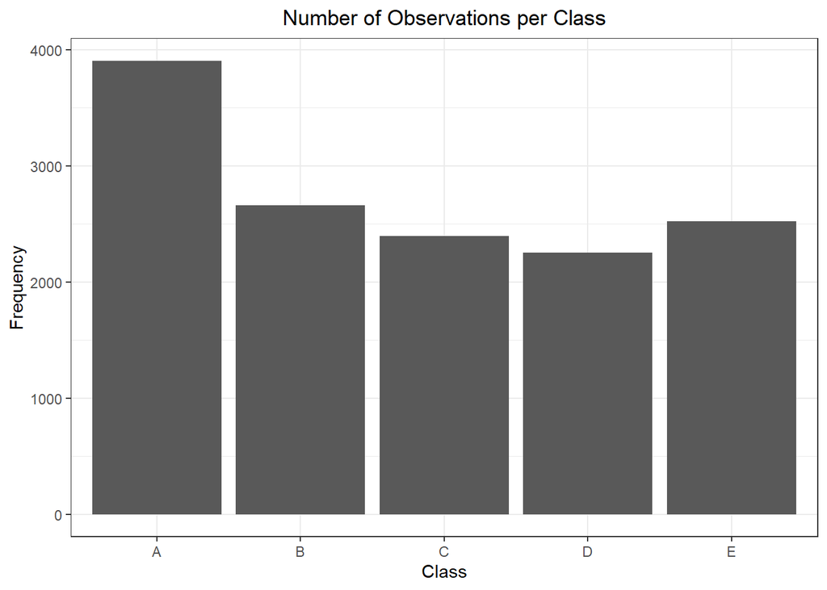

```r
pml_train %>% count(classe) %>% ggplot(aes(classe, n)) +
    geom_col() +
    theme_bw() +
    labs(title = 'Number of Observations per Class',
         x = 'Class', y = 'Frequency') +
    theme(plot.title = element_text(hjust = 0.5))
```

The classes appear to be fairly balanced although there do seem to be more observations in the `A` classe compared to the other classes. Overall, no further transformations on the features are required.

# Feature selection

With our remaining features we will now perform feature selection using Correlation-based Feature Selection (CFS). For our purposes, we will use the implementation of CFS provided in the `FSelector` package.

```r
# Load FSelector package
library(FSelector)

# Perform feature selection using CFS
best_features <- cfs(classe ~ ., pml_train)

# Display the selected features
best_features
```

```
## [1] "roll_belt"         "pitch_belt"        "yaw_belt"
## [4] "magnet_arm_x"      "gyros_dumbbell_y"  "magnet_dumbbell_y"
## [7] "pitch_forearm"
```

```r
pml_train_best_feats <- pml_train %>% select(all_of(best_features), classe)
```

# Model training and evaluation

## Training the model

For this project, we will use an XGBoost tree classifier. The training process includes hyperparameter tuning using a grid search with 5-fold cross validation to select the best set of hyperparameters for our model. Additionally, we will be making use of the `doParallel` library in order to speed up model training.

```r
# Load the necessary libraries
library(xgboost)
library(doParallel)

# Set cross validation parameters for caret's train function and create
# hyperparamter grid
tr_ctrl <- trainControl(method = 'cv', number = 5)
xgb_tune <- expand.grid(nrounds = c(50, 100, 150),
                        max_depth = c(1, 3, 5, 7),
                        eta = c(0.01, 0.1, 0.5),
                        gamma = c(0.1, 0.5, 1, 5, 10, 50),
                        colsample_bytree = c(1, 3, 5),
                        min_child_weight = c(1, 3, 5),
                        subsample = c(0.5, 0.6, 0.7, 0.8))

# Train model with parallel processing enabled
set.seed(56765)

cl <- makeForkCluster(detectCores() - 1)
registerDoParallel(cl)
pml_xgb <- train(classe ~ ., data = pml_train_best_feats, method = 'xgbTree',
                 trControl = tr_ctrl, tuneGrid = xgb_tune, nthread = 1)
stopCluster(cl)
```

## Evaluating the model

### Out-of-sample error

Before we evaluate our model, it is worth taking a look at the out-of-sample error rate of our model. We will also compute and display the mean out-of-sample accuracy as that is the standard means of measuring the performance of a classifier.

```r
# Get mean out-of-sample accuracy
oos_accuracy <- pml_xgb$resample %>%
    summarize(oos_accuracy = mean(Accuracy)) %>%
    pluck('oos_accuracy')

oos_error <- 1 - oos_accuracy
```

We find that the out-of-sample accuracy is 0.9757 while the out-of-sample error is 0.0243. Both metrics indicate that our model will perform well on new data.

### Confusion matrix, precision, recall, and F1 score

Below is the confusion matrix of our model’s predictions on the test set.

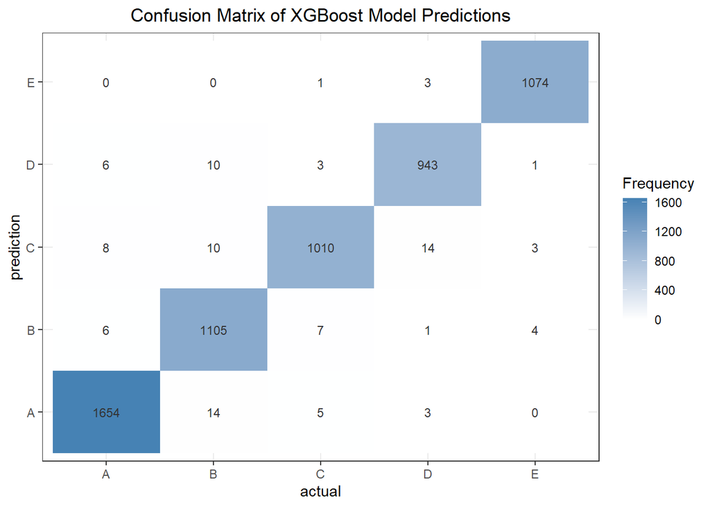

```r
# Save confusion matrix object
conf_mat <- confusionMatrix(predict(pml_xgb, pml_test), pml_test$classe,
                            mode = 'prec_recall')

# Get and prep table from confusion matrix objec
conf_mat_tibble <- conf_mat$table %>% as_tibble() %>%
    rename(prediction = Prediction, actual = Reference, freq = n)

# Plot confusion matrix
conf_mat_tibble %>% ggplot(aes(x = actual, y = prediction, fill = freq)) +
    geom_tile() +
    geom_text(aes(label = freq), size = 3, color = 'gray20') +
    scale_fill_gradient(low = 'white', high = 'steelblue', name = 'Frequency') +
    theme_bw() +
    theme(plot.title = element_text(hjust = 0.5)) +
    labs(title = 'Confusion Matrix of XGBoost Model Predictions')
```

Here we can see that the model seems to do a good job overall in predicting the correct classes. This is particularly true of the `E` class, where the majority of the predictions were correct with few false positives and false negatives. While the other classes had comparitively more false positives and false negatives, the total amounts of both types of errors is small relative to the total number of instances in each class. This is reflected in the per-class precision, recall, and F1 metrics shown below.

```r
# Display the per-class metrics
conf_mat %>% as.matrix(what = 'classes') %>%
    as.data.frame() %>% .[5:7 , ] %>%
    knitr::kable() %>%
    kableExtra::kable_styling(bootstrap_options = 'striped', full_width = F,
                              position = 'center')
```

|  | A | B | C | D | E |
| --- | --- | --- | --- | --- | --- |
| Precision | 0.9868735 | 0.9839715 | 0.9665072 | 0.9792316 | 0.9962894 |
| Recall | 0.9880526 | 0.9701493 | 0.9844055 | 0.9782158 | 0.9926063 |
| F1 | 0.9874627 | 0.9770115 | 0.9753742 | 0.9787234 | 0.9944444 |

The values of each metric for each class are all close to 1 indicating that the model is able to correctly identify a given class over the vast majority of instances.

```r
overall_metrics <- conf_mat %>% as.matrix(what = 'overall') %>%
    as.data.frame() %>%
    rename(value = V1)

# Display the overall metrics
overall_metrics %>%
    knitr::kable() %>%
    kableExtra::kable_styling(bootstrap_options = 'striped', full_width = F,
                              position = 'center')
```

|  | value |
| --- | --- |
| Accuracy | 0.9831776 |
| Kappa | 0.9787224 |
| AccuracyLower | 0.9795569 |
| AccuracyUpper | 0.9863071 |
| AccuracyNull | 0.2844520 |
| AccuracyPValue | 0.0000000 |
| McnemarPValue | NaN |

The value of the model’s accuracy and kappa metrics also seem to show that the model’s overall performance is quite good. In fact, the accuracy is slightly higher than the out-of-sample accuracy that we calculated earlier which is surprising given that the cross-validation error is a pessimistic estimate. The test set accuracy gives us a slightly lower error of 0.0168.